# Women in Parliament - Tidy Data

qui 12 dez 2019 (19:49:16)

[figure not shown]

# Objectives

*Explore the geographical and time trends for the percentage of women in national parliaments.*

# Understanding the Data

## The World Bank Data

The raw data for *“Proportion of seats held by women in national parliaments”* includes the percentage of women in parliament (*“single or lower parliamentary chambers only”*) by country (region) and year. It can be downloaded from:

- https://data.worldbank.org/indicator/SG.GEN.PARL.ZS

As part of its “open data” mission the World Bank offers *“free and open access to global development data”* kindly licensed under the “Creative Commons Attribution 4.0 (CC-BY 4.0)”.

## Source Data

The data originates from the “Inter-Parliamentary Union” (IPU)[^ipuwebsite] which provides an *“Archive of statistical data on the percentage of women in national parliaments”* going back to 1997 on a monthly basis:

- http://archive.ipu.org/wmn-e/classif-arc.htm

The World Bank data is for “single or lower parliamentary chambers only”, while the IPU also presents data for “Upper Houses or Senates”. Moreover, the IPU provides the actual numbers used to calculate the percentages (which the World Bank does not).

## Data limitations

Take caution when interpreting these data, as parliamentary systems vary from country to country, and in some cases over time. Some of the issues to consider include:

- Who has, and who does not have, the right to become a Member of Parliament (MP)?
- How does someone become an MP? Through democratic elections? How is “democratic election” defined?
- What is the real power of MPs and their parliament? Can MPs make a difference?

## Data definitions & assumptions

### “Women”

The definition for “women” is not given, so we will assume that it refers to a binary classification for gender (sex).

### “Country (Region)”

The definition of countries and regions can change over time. (e.g. formation of new countries after conflicts, new member states joining a pre-existing collective). How are these changes reflected in the data? How do they affect the interpretation?

## Pro tip

Understand the limitations of your data before anybody else points them out to you.

# About the data file

The data is stored in a file called: `API_SG.GEN.PARL.ZS_DS2_en_csv_v2_511371.csv`

To simplify things we have copied it to `WB-WiP.csv` (which also allows us to maintain the original file in case something goes wrong).

## Pro tip

Always keep a backup copy of the data. Alternatively, set the data file(s) to “read-only” to protect it from being overwritten or modified.

# Importing the data

```r
library(data.table)
library(here)
wip <- fread(here("data", "WB-WiP.csv"),
             skip = 4, header = TRUE,
             check.names = TRUE)
```

```r
wip[, .N, by=.(V65)]
```

```
##    V65   N
## 1:  NA 264
```

```r
wip[, .N, by=.(Indicator.Name)]
```

```
##                                                   Indicator.Name   N
## 1: Proportion of seats held by women in national parliaments (%) 264
```

```r
wip[, .N, by=.(Indicator.Code)]
```

```
##    Indicator.Code   N
## 1: SG.GEN.PARL.ZS 264
```

# Data Wrangling

```r
wip[, c("Indicator.Name", "Indicator.Code", "V65"):=NULL]
setnames(wip, c("Country.Name" , "Country.Code"), c("Country" , "Code"))
head(names(wip))
```

```
## [1] "Country" "Code"    "X1960"   "X1961"   "X1962"   "X1963"
```

```r
tail(names(wip))
```

```
## [1] "X2014" "X2015" "X2016" "X2017" "X2018" "X2019"
```

```r
WP <- melt(wip,
           id.vars = c("Country" , "Code"),
           measure = patterns("^X"),
           variable.name = "YearC",
           value.name = c("pctWIP"),
           na.rm = TRUE)
WP
```

```
##                    Country Code YearC    pctWIP
##    1:          Afghanistan  AFG X1990  3.700000
##    2:               Angola  AGO X1990 14.500000
##    3:              Albania  ALB X1990 28.800000
##    4:           Arab World  ARB X1990  3.891439
##    5: United Arab Emirates  ARE X1990  0.000000
##   ---
## 5105:                Samoa  WSM X2018 10.000000
## 5106:          Yemen, Rep.  YEM X2018  0.000000
## 5107:         South Africa  ZAF X2018 42.300000
## 5108:               Zambia  ZMB X2018 18.000000
## 5109:             Zimbabwe  ZWE X2018 31.500000
```

```r
WP[, `:=`(Year=as.numeric(gsub("[^[:digit:].]",
                               "", YearC)),
          Ratio = (100-pctWIP)/pctWIP)][
            , YearC:=NULL
          ]
WP
```

```
##                    Country Code    pctWIP Year     Ratio
##    1:          Afghanistan  AFG  3.700000 1990 26.027027
##    2:               Angola  AGO 14.500000 1990  5.896552
##    3:              Albania  ALB 28.800000 1990  2.472222
##    4:           Arab World  ARB  3.891439 1990 24.697433
##    5: United Arab Emirates  ARE  0.000000 1990       Inf
##   ---
## 5105:                Samoa  WSM 10.000000 2018  9.000000
## 5106:          Yemen, Rep.  YEM  0.000000 2018       Inf
## 5107:         South Africa  ZAF 42.300000 2018  1.364066
## 5108:               Zambia  ZMB 18.000000 2018  4.555556
## 5109:             Zimbabwe  ZWE 31.500000 2018  2.174603
```

# Exploratory Analysis

```r
WP[Country %in% "Portugal"]
```

```
##      Country Code pctWIP Year     Ratio
##  1: Portugal  PRT    7.6 1990 12.157895
##  2: Portugal  PRT   13.0 1997  6.692308
##  3: Portugal  PRT   13.0 1998  6.692308
##  4: Portugal  PRT   18.7 1999  4.347594
##  5: Portugal  PRT   17.4 2000  4.747126
##  6: Portugal  PRT   18.7 2001  4.347594
##  7: Portugal  PRT   19.1 2002  4.235602
##  8: Portugal  PRT   19.1 2003  4.235602
##  9: Portugal  PRT   19.1 2004  4.235602
## 10: Portugal  PRT   21.3 2005  3.694836
## 11: Portugal  PRT   21.3 2006  3.694836
## 12: Portugal  PRT   28.3 2007  2.533569
## 13: Portugal  PRT   28.3 2008  2.533569
## 14: Portugal  PRT   27.4 2009  2.649635
## 15: Portugal  PRT   27.4 2010  2.649635
## 16: Portugal  PRT   28.7 2011  2.484321
## 17: Portugal  PRT   28.7 2012  2.484321
## 18: Portugal  PRT   28.7 2013  2.484321
## 19: Portugal  PRT   31.3 2014  2.194888
## 20: Portugal  PRT   34.8 2015  1.873563
## 21: Portugal  PRT   34.8 2016  1.873563
## 22: Portugal  PRT   34.8 2017  1.873563
## 23: Portugal  PRT   34.8 2018  1.873563
##      Country Code pctWIP Year     Ratio
```

```r
WP[Country %in% "Canada"]
```

```
##     Country Code pctWIP Year    Ratio
##  1:  Canada  CAN   13.3 1990 6.518797
##  2:  Canada  CAN   20.6 1997 3.854369
##  3:  Canada  CAN   20.6 1998 3.854369
##  4:  Canada  CAN   20.6 1999 3.854369
##  5:  Canada  CAN   20.6 2001 3.854369
##  6:  Canada  CAN   20.6 2002 3.854369
##  7:  Canada  CAN   20.6 2003 3.854369
##  8:  Canada  CAN   21.1 2004 3.739336
##  9:  Canada  CAN   21.1 2005 3.739336
## 10:  Canada  CAN   20.8 2006 3.807692
## 11:  Canada  CAN   21.3 2007 3.694836
## 12:  Canada  CAN   22.1 2008 3.524887
## 13:  Canada  CAN   22.1 2009 3.524887
## 14:  Canada  CAN   22.1 2010 3.524887
## 15:  Canada  CAN   24.8 2011 3.032258
## 16:  Canada  CAN   24.7 2012 3.048583
## 17:  Canada  CAN   24.7 2013 3.048583
## 18:  Canada  CAN   25.1 2014 2.984064
## 19:  Canada  CAN   26.0 2015 2.846154
## 20:  Canada  CAN   26.0 2016 2.846154
## 21:  Canada  CAN   26.3 2017 2.802281
## 22:  Canada  CAN   27.0 2018 2.703704
##     Country Code pctWIP Year    Ratio
```

```r
WP[Country %in% "Japan"]
```

```
##     Country Code pctWIP Year     Ratio
##  1:   Japan  JPN    1.4 1990 70.428571
##  2:   Japan  JPN    4.6 1997 20.739130
##  3:   Japan  JPN    4.6 1998 20.739130
##  4:   Japan  JPN    4.6 1999 20.739130
##  5:   Japan  JPN    7.3 2000 12.698630
##  6:   Japan  JPN    7.3 2001 12.698630
##  7:   Japan  JPN    7.3 2002 12.698630
##  8:   Japan  JPN    7.1 2003 13.084507
##  9:   Japan  JPN    7.1 2004 13.084507
## 10:   Japan  JPN    9.0 2005 10.111111
## 11:   Japan  JPN    9.4 2006  9.638298
## 12:   Japan  JPN    9.4 2007  9.638298
## 13:   Japan  JPN    9.4 2008  9.638298
## 14:   Japan  JPN   11.3 2009  7.849558
## 15:   Japan  JPN   11.3 2010  7.849558
## 16:   Japan  JPN   10.8 2011  8.259259
## 17:   Japan  JPN    7.9 2012 11.658228
## 18:   Japan  JPN    8.1 2013 11.345679
## 19:   Japan  JPN    8.1 2014 11.345679
## 20:   Japan  JPN    9.5 2015  9.526316
## 21:   Japan  JPN    9.5 2016  9.526316
## 22:   Japan  JPN    9.3 2017  9.752688
## 23:   Japan  JPN   10.1 2018  8.900990
##     Country Code pctWIP Year     Ratio
```

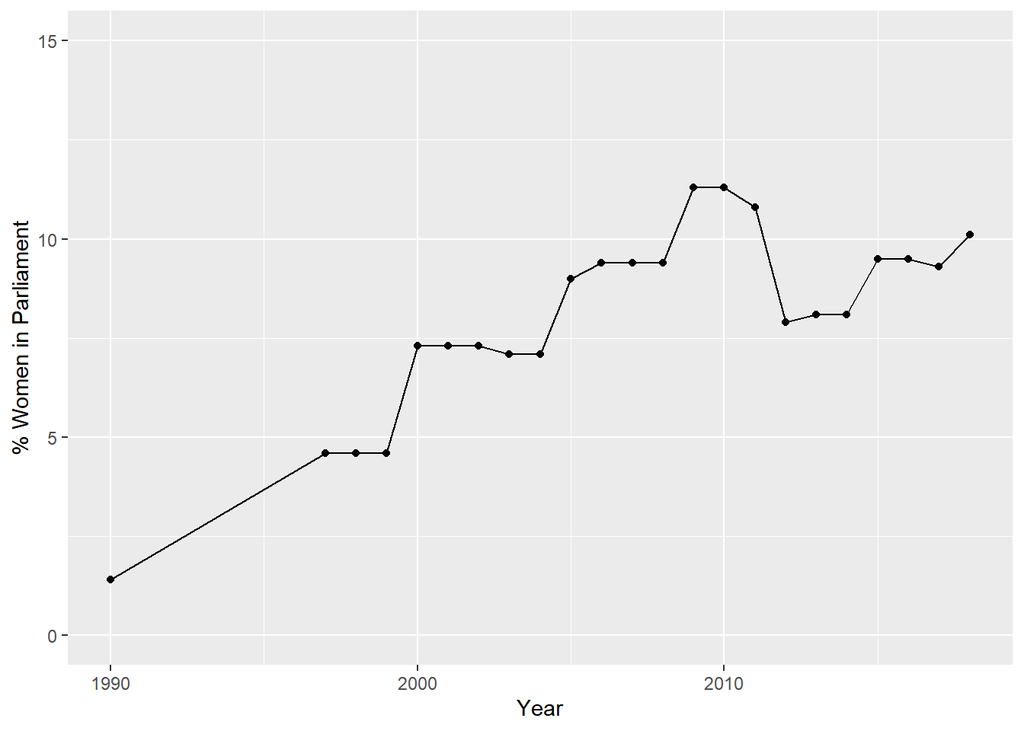

```r
library(ggplot2)
library(magrittr)
WP[Country %in% "Japan"] %>%
  ggplot(aes(Year, pctWIP)) +
    geom_line() + geom_point() +
    scale_y_continuous(limits = c(0,15)) +
    ylab("% Women in Parliament")
```

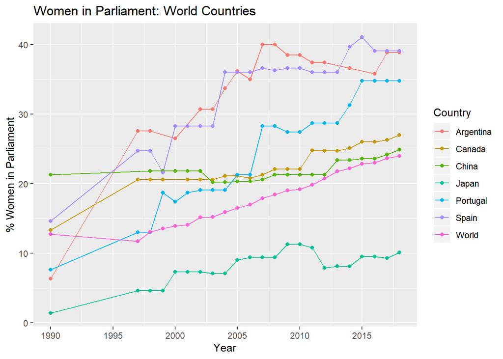

```r
WP[Country %in% c("Portugal", "Japan", "Spain", "China", "Canada", "Argentina", "World")] %>%
  ggplot(aes(Year, pctWIP, colour = Country))+
    geom_line() +
    geom_point() +
    scale_x_continuous(breaks = seq(1990,2020,5)) +
    ggtitle("Women in Parliament: World Countries") +
    ylab("% Women in Parliament")
```

```r
WP[order(-pctWIP), head(.SD,10)]
```

```
##     Country Code pctWIP Year     Ratio
##  1:  Rwanda  RWA   63.8 2013 0.5673981
##  2:  Rwanda  RWA   63.8 2014 0.5673981
##  3:  Rwanda  RWA   63.8 2015 0.5673981
##  4:  Rwanda  RWA   63.8 2016 0.5673981
##  5:  Rwanda  RWA   61.3 2017 0.6313214
##  6:  Rwanda  RWA   61.3 2018 0.6313214
##  7:  Rwanda  RWA   56.3 2008 0.7761989
##  8:  Rwanda  RWA   56.3 2009 0.7761989
##  9:  Rwanda  RWA   56.3 2010 0.7761989
## 10:  Rwanda  RWA   56.3 2011 0.7761989
```

```r
WP[order(Year, -pctWIP), head(.SD, 1), by= Year]
```

```
##     Year Country Code pctWIP     Ratio
##  1: 1990  Sweden  SWE   38.4 1.6041667
##  2: 1997  Sweden  SWE   40.4 1.4752475
##  3: 1998  Sweden  SWE   40.4 1.4752475
##  4: 1999  Sweden  SWE   42.7 1.3419204
##  5: 2000  Sweden  SWE   42.7 1.3419204
##  6: 2001  Sweden  SWE   42.7 1.3419204
##  7: 2002  Sweden  SWE   45.0 1.2222222
##  8: 2003  Rwanda  RWA   48.8 1.0491803
##  9: 2004  Rwanda  RWA   48.8 1.0491803
## 10: 2005  Rwanda  RWA   48.8 1.0491803
## 11: 2006  Rwanda  RWA   48.8 1.0491803
## 12: 2007  Rwanda  RWA   48.8 1.0491803
## 13: 2008  Rwanda  RWA   56.3 0.7761989
## 14: 2009  Rwanda  RWA   56.3 0.7761989
## 15: 2010  Rwanda  RWA   56.3 0.7761989
## 16: 2011  Rwanda  RWA   56.3 0.7761989
## 17: 2012  Rwanda  RWA   56.3 0.7761989
## 18: 2013  Rwanda  RWA   63.8 0.5673981
## 19: 2014  Rwanda  RWA   63.8 0.5673981
## 20: 2015  Rwanda  RWA   63.8 0.5673981
## 21: 2016  Rwanda  RWA   63.8 0.5673981
## 22: 2017  Rwanda  RWA   61.3 0.6313214
## 23: 2018  Rwanda  RWA   61.3 0.6313214
##     Year Country Code pctWIP     Ratio
```

```r
library(countrycode)
c1 <- as.data.table(codelist)[,.(continent, wb)]
setnames(c1, c("continent", "wb"), c("Continent","Code"))
cWP <- c1[WP, on="Code"] #Faz merge às duas data.tables em que os valores na coluna Code sejam iguais
```

```r
cWP[Year %in% c(1990, 2018) & !is.na(Continent)][       #Remove as linhas que têm NAs
  order(Year, -pctWIP), head(.SD,1),
  by= .(Year,Continent)][
    order(Continent,Year), .(Continent, Year, Country, pctWIP)]
```

```
##     Continent Year       Country pctWIP
##  1:    Africa 1990 Guinea-Bissau   20.0
##  2:    Africa 2018        Rwanda   61.3
##  3:  Americas 1990        Guyana   36.9
##  4:  Americas 2018          Cuba   53.2
##  5:      Asia 1990       Armenia   35.6
##  6:      Asia 2018   Timor-Leste   33.8
##  7:    Europe 1990        Sweden   38.4
##  8:    Europe 2018        Sweden   46.1
##  9:   Oceania 1990   New Zealand   14.4
## 10:   Oceania 2018   New Zealand   38.3
```

```r
dWP <- cWP[order(Country, Year), .SD[c(1,.N)], by=Country][
  , pctDiff:= pctWIP - shift(pctWIP), by=Country][
    pctDiff<0][
      order(pctDiff)]
dWP[!is.na(Continent), .(Country, pctWIP, pctDiff)]
```

```
##                         Country pctWIP pctDiff
##  1:                     Armenia   18.1   -17.5
##  2:                     Romania   20.7   -13.7
##  3:                     Hungary   12.6    -8.1
##  4:                    Mongolia   17.1    -7.8
##  5:               Guinea-Bissau   13.7    -6.3
##  6:                      Guyana   31.9    -5.0
##  7: Korea, Dem. Peopleâ\200\231s Rep.   16.3    -4.8
##  8:                     Vanuatu    0.0    -4.3
##  9:                 Yemen, Rep.    0.0    -4.1
## 10:                        Mali    8.8    -3.4
## 11:                 Congo, Rep.   11.3    -3.0
## 12:                        Oman    1.2    -1.2
## 13:                Turkmenistan   24.8    -1.2
## 14:                       Haiti    2.5    -1.1
## 15:                      Tuvalu    6.7    -1.0
## 16:                     Albania   27.9    -0.9
## 17:                    Maldives    5.9    -0.4
```

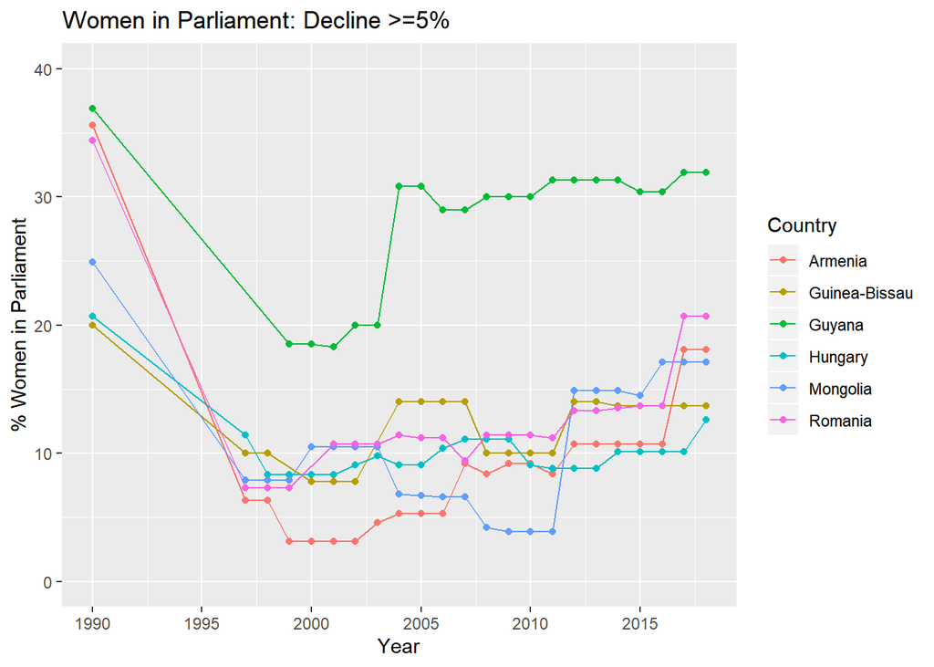

```r
dclpct <- unique(dWP[!is.na(Continent) & pctDiff <= -5]$Country)
WP[Country %in% dclpct] %>%
  ggplot(aes(Year, pctWIP, colour= Country))+
  geom_line()+
  geom_point()+
  scale_x_continuous(breaks = seq(1990,2020,5))+
  scale_y_continuous(limits = c(0,40), breaks=seq(0,40,10))+
  ggtitle("Women in Parliament: Decline >=5%")+
  ylab("% Women in Parliament")
```

```r
cWP[!is.na(Continent), `:=`(RankG = rank(-pctWIP), TotalG = .N), by= .(Year)]
cWP[Country=="Portugal", .(Country, Year, pctWIP, Ratio, RankG, TotalG)]
```

```
##      Country Year pctWIP     Ratio RankG TotalG
##  1: Portugal 1990    7.6 12.157895  66.0    138
##  2: Portugal 1997   13.0  6.692308  41.5    161
##  3: Portugal 1998   13.0  6.692308  49.5    163
##  4: Portugal 1999   18.7  4.347594  24.0    154
##  5: Portugal 2000   17.4  4.747126  34.0    158
##  6: Portugal 2001   18.7  4.347594  33.0    168
##  7: Portugal 2002   19.1  4.235602  41.0    161
##  8: Portugal 2003   19.1  4.235602  46.0    175
##  9: Portugal 2004   19.1  4.235602  54.0    182
## 10: Portugal 2005   21.3  3.694836  45.5    185
## 11: Portugal 2006   21.3  3.694836  49.5    189
## 12: Portugal 2007   28.3  2.533569  28.0    188
## 13: Portugal 2008   28.3  2.533569  28.0    187
## 14: Portugal 2009   27.4  2.649635  33.0    187
## 15: Portugal 2010   27.4  2.649635  34.0    187
## 16: Portugal 2011   28.7  2.484321  31.0    188
## 17: Portugal 2012   28.7  2.484321  35.0    188
## 18: Portugal 2013   28.7  2.484321  39.0    186
## 19: Portugal 2014   31.3  2.194888  35.0    187
## 20: Portugal 2015   34.8  1.873563  29.0    188
## 21: Portugal 2016   34.8  1.873563  27.0    191
## 22: Portugal 2017   34.8  1.873563  28.0    192
## 23: Portugal 2018   34.8  1.873563  29.0    192
##      Country Year pctWIP     Ratio RankG TotalG
```

```r
cWP[!is.na(Continent), `:=`(RankC = rank(-pctWIP), TotalC = .N), by= .(Continent, Year)]
cWP[Country=="Portugal", .(Country, Year, pctWIP, Ratio, RankC, TotalC)][ order((Year))]
```

```
##      Country Year pctWIP     Ratio RankC TotalC
##  1: Portugal 1990    7.6 12.157895  22.0     28
##  2: Portugal 1997   13.0  6.692308  16.5     39
##  3: Portugal 1998   13.0  6.692308  18.5     37
##  4: Portugal 1999   18.7  4.347594  12.0     38
##  5: Portugal 2000   17.4  4.747126  16.0     38
##  6: Portugal 2001   18.7  4.347594  15.0     41
##  7: Portugal 2002   19.1  4.235602  15.0     39
##  8: Portugal 2003   19.1  4.235602  17.0     41
##  9: Portugal 2004   19.1  4.235602  21.0     42
## 10: Portugal 2005   21.3  3.694836  20.0     42
## 11: Portugal 2006   21.3  3.694836  21.0     44
## 12: Portugal 2007   28.3  2.533569  15.0     44
## 13: Portugal 2008   28.3  2.533569  13.0     44
## 14: Portugal 2009   27.4  2.649635  15.0     44
## 15: Portugal 2010   27.4  2.649635  15.0     44
## 16: Portugal 2011   28.7  2.484321  14.0     44
## 17: Portugal 2012   28.7  2.484321  15.0     43
## 18: Portugal 2013   28.7  2.484321  17.0     43
## 19: Portugal 2014   31.3  2.194888  16.0     43
## 20: Portugal 2015   34.8  1.873563  12.0     43
## 21: Portugal 2016   34.8  1.873563  11.0     43
## 22: Portugal 2017   34.8  1.873563  12.0     43
## 23: Portugal 2018   34.8  1.873563  12.0     43
##      Country Year pctWIP     Ratio RankC TotalC
```

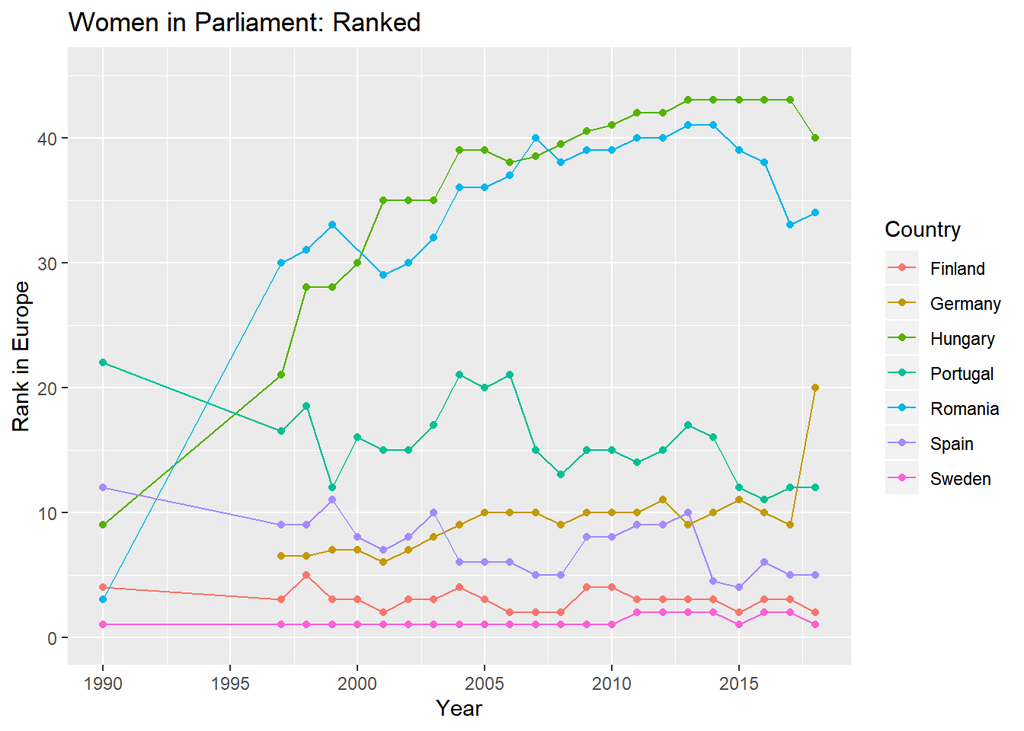

```r
cWP[ Country %in% c("Portugal", "Sweden", "Spain", "Hungary", "Romania", "Finland", "Germany")] %>%
  ggplot(aes(Year, RankC, colour=Country))+
    geom_line()+
    geom_point()+
    scale_x_continuous(breaks = seq(1990,2020,5))+
    scale_y_continuous(limits = c(0,45), breaks = seq(0,45,10))+
    ggtitle("Women in Parliament: Ranked")+
    ylab("Rank in Europe")
```

```r
cWP[Year %in% c(1990,2018) & RankC==1][
  order(Continent, Year), .(Continent, Year, Country, pctWIP, RankC)]
```

```
##     Continent Year       Country pctWIP RankC
##  1:    Africa 1990 Guinea-Bissau   20.0     1
##  2:    Africa 2018        Rwanda   61.3     1
##  3:  Americas 1990        Guyana   36.9     1
##  4:  Americas 2018          Cuba   53.2     1
##  5:      Asia 1990       Armenia   35.6     1
##  6:      Asia 2018   Timor-Leste   33.8     1
##  7:    Europe 1990        Sweden   38.4     1
##  8:    Europe 2018        Sweden   46.1     1
##  9:   Oceania 1990   New Zealand   14.4     1
## 10:   Oceania 2018   New Zealand   38.3     1
```

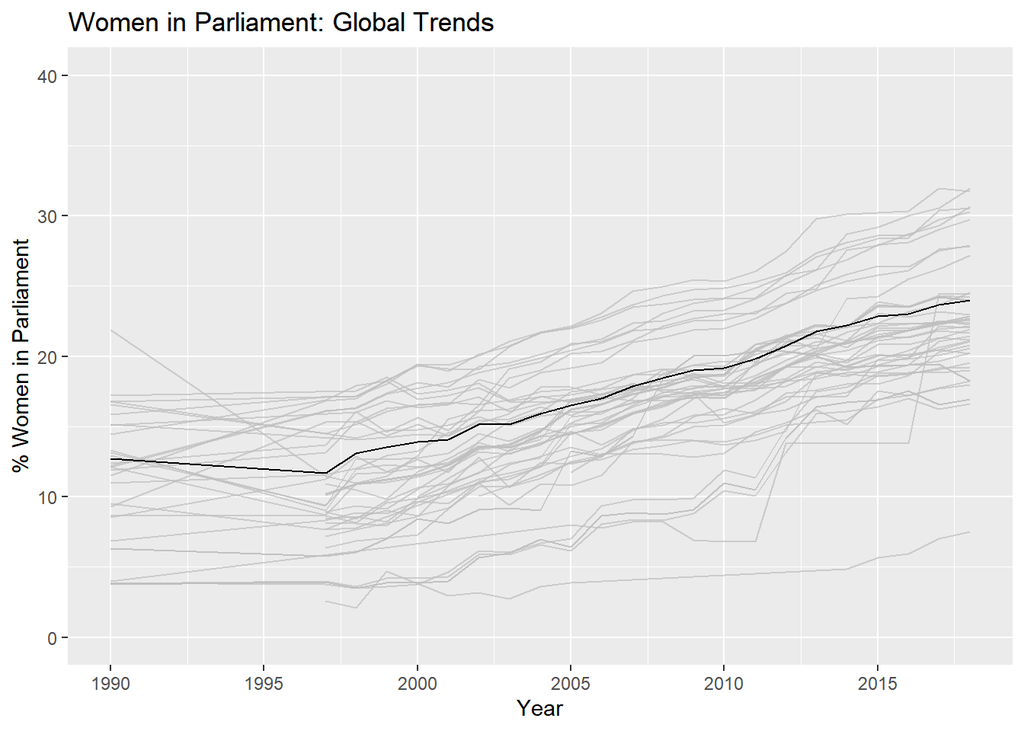

[figure not shown]

```r
library(gghighlight)
cWP[is.na(Continent)] %>%
  ggplot(aes(Year, pctWIP, group=Country))+
    geom_line()+
    gghighlight(Country=="World", use_direct_label = FALSE)+
    scale_x_continuous(breaks = seq(1990,2020,5))+
    scale_y_continuous(limits = c(0,40), breaks = seq(0,40,10))+
    ggtitle("Women in Parliament: Global Trends")+
    ylab("% Women in Parliament")
```